# Week 2 Solutions

Stavrina Dimosthenous

02/02/2022

## Part 1: Load data

Load data and suppress details in console

```r
course_details <- read_csv("../../../week-02-data-wrangling/course_details.csv", show_col_types = FALSE)
starts <- read_csv("../../../week-02-data-wrangling/starts.csv", show_col_types = FALSE)
ofsted <- read_csv("../../../week-02-data-wrangling/ofsted.csv", show_col_types = FALSE)
ofsted_scores <- read_csv("../../../week-02-data-wrangling/ofsted_scores.csv", show_col_types = FALSE)
# spec(course_details) # lists all columns and column types for given tibble
```

## Part 2: Wrangle

```r
# Sort providers by name and how many times the name appears in the dataset
ofsted %>% count(provider_name, sort = TRUE)

# Same as above to check uniqueness
ofsted %>% count(ukprn, sort = TRUE)

# Use count() and summarise() to generate a tibble with proportions of provider types across sum of provider types for each learning provider
ofsted %>%
  count(provider_type) %>%
  summarise(provider_type, prop = n / sum(n))

# Join ofsted and ofsted_scores
ofsted_joined <- left_join(ofsted, ofsted_scores, by = c("inspection_number" = "inspection_id"))

# Count percentage of inspections with ineffective safeguarding
ofsted_joined %>%
  group_by(inspection_category) %>%
  count(score_description) %>%
  summarise(score_description, "score_decription_percentage" = 100 * n / sum(n), .groups = "drop")

# Convert "inspection_date" to date type
inspection_trends <- ofsted %>%
  mutate(inspection_date = lubridate::as_date(inspection_date, format = "%Y.%m.%d"),
         day_of_week = wday(inspection_date, label = T, abbr = F)) %>%
  filter(!is.na(day_of_week))

# inspection_trends %>%
#   ggplot(mapping = aes(dayofweek)) +
#   geom_bar() +
#   labs(x = "Day of the Week", y = "Number of inspections")

# inspection_trends %>%
#   ggplot(mapping = aes(x = dayofweek, fill = inspection_type)) +
#   geom_bar() +
#   scale_fill_brewer(palette = "Set2", labels = scales::label_wrap(15)) +
#   labs(x = "Day of the Week", y = "Number of inspections", fill = "Inspection Type")
```

### Answers

1. One provider name (Health Education England) shows up twice
2. All UKPRN are unique
3. 108 out of 2053 or 0.053 (2 s.f.)
4. 0.69 % (2 s.f.)
5. Convert to day of week
   - From the resulting bar chart, the day of the week with the most inspections is Tuesday.

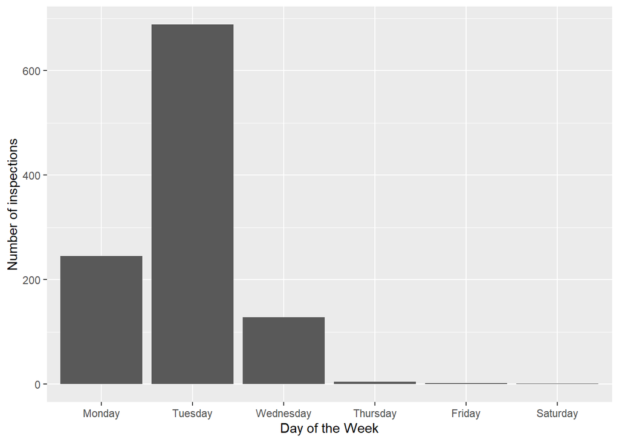

   - Yes but not to a significant degree. Between the two inspection types, there was a higher number of short inspections performed on Wednesdays compared to Tuesdays.

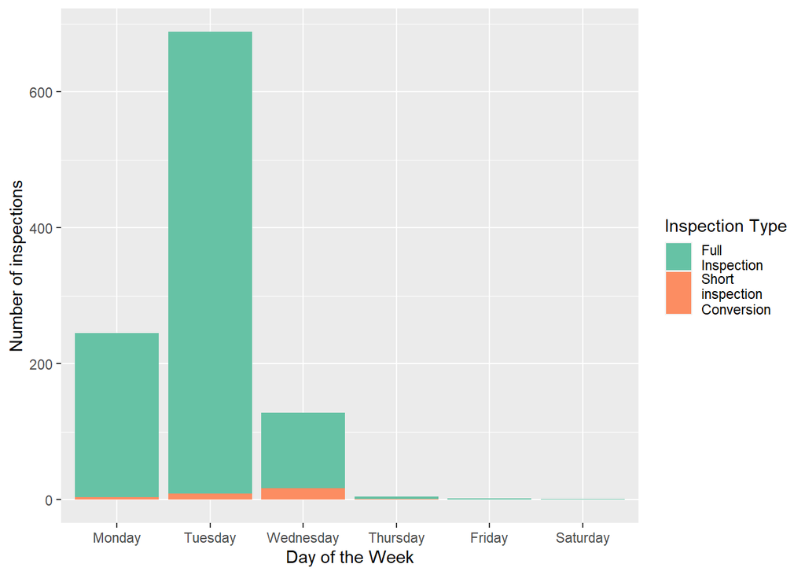

## Part 3:

```r
# Task 1
# Code below is what I ran to get the proportion for provider_type grouping
ofsted_joined %>%
  filter(inspection_category == "Apprenticeships") %>%
  group_by(provider_type, score_description) %>%
  summarise(n = n(), .groups = "drop_last") %>%
  mutate(prop = round(n / sum(n), digits = 2)) %>%
  filter(score_description == "Outstanding") %>%
  arrange(score_description, desc(prop)) %>%
  ungroup()

# Code below creates a table with provider grouping
# Take the left join table and group by provider type and score, summarise will count the number of score
# descriptions of each type associated with each provider type
# "drop_last" flag explicit for my benefit, mostly
# add a proportion column measuring the proportion across the scores for each provider type
# arrange them for readibility
score_prop <- ofsted_joined %>%
  filter(inspection_category == "Apprenticeships") %>%
  group_by(provider_type, score_description) %>%
  summarise(n = n(), .groups = "drop_last") %>%
  mutate(prop = round(n / sum(n), 2)) %>%
  arrange(score_description, desc(prop)) %>%
  ungroup()

# Task 2 Create lookup table by pivoting
score_lookup <- drop_na(score_prop) %>%
  select(!n) %>%
  pivot_wider(names_from = score_description, values_from = prop) %>%
  janitor::clean_names()
# Output via knitr kable() within markdown document

# Task 3 Determine total starts associated with each inspection score where the inspection category is "Overall effectiveness"

# Left join previously created "ofsted_joined" to starts table (only on key and number of starts, i.e. "ukprn" and "starts")
# NOTE to self: inner join removes NaN and NA
overall_starts <- inner_join(filter(ofsted_joined, inspection_category == "Overall effectiveness" | inspection_category == "Apprenticeships"),summarise(starts, ukprn, starts), by = "ukprn")

# Determine total number of starts by grouping by score description and summarising with a sum over groupings
# remove any rows with NA or NaN first - failsafe, I guess?
starts_score_description <- overall_starts %>%
  filter(inspection_category == "Overall effectiveness") %>%
  group_by("Score Description" = score_description) %>%
  summarise("Total starts" = sum(starts))

# Task 4 Determine total apprenticeship starts associated with each inspection score
total_apprenticeship_starts <- overall_starts %>%
  filter(inspection_category == "Apprenticeships") %>%
  group_by("Score Description" = score_description) %>%
  summarise("Total starts" = sum(starts))
```

### Answers

1. Employer Providers have the highest proportion of “Outstanding” scores based across all inspections of Employer Providers
2. Proportion of score descriptions by provider group types

| provider_type | outstanding | good | requires_improvement | inadequate |
| --- | --- | --- | --- | --- |
| Employer provider | 0.20 | 0.53 | 0.24 | 0.02 |
| General further education college | 0.12 | 0.53 | 0.35 | NA |
| Higher education institution | 0.04 | 0.83 | 0.12 | NA |
| Independent learning provider | 0.05 | 0.74 | 0.17 | 0.04 |
| Independent specialist college | NA | 0.33 | 0.33 | 0.33 |
| Local authority provider | 0.05 | 0.85 | 0.10 | NA |
| Sixth-form college | NA | 0.60 | NA | 0.40 |
| Specialist further education college | NA | 0.86 | 0.14 | NA |

3. Total starts for each ofsted score associated with “Overall effectiveness” inspections (alphabetical order):

| Score Description | Total starts |
| --- | --- |
| Good | 585222 |
| Inadequate | 5443 |
| Outstanding | 98458 |
| Requires improvement | 94513 |

4. Total apprenticeship starts associated with each ofsted score:
   - While there is approximately a 130,000 difference between overall scoring and apprenticeship starts, the spread in scoring proportions is similar, at first glance. In both cases, the majority of providers scored “good”, and the total starts in providers scoring “inadequate” are approximately 1% of starts in providers scoring “good”. However, in the overall scoring the number of starts in providers scoring “outstanding” is approximately the same as providers scoring “requires improvement”, while in the apprenticeships specific scoring we see that there is about a difference of 28000 between starts in providers scoring “outstanding” and providers scoring “requires improvement”, where fewer providers scored “outstanding” for apprenticeships. This implies that there are cases where providers might be performing well overall but under performing, in comparison, in apprenticeships.

| Score Description | Total starts |
| --- | --- |
| Good | 467032 |
| Inadequate | 4544 |
| Outstanding | 76961 |
| Requires improvement | 103563 |